# Ciência de Dados - Séries Univariadas

Brenner Biasi, Herica Oliveira e Lucas Mascarenhas

15 de janeiro de 2019

## ENGF08 - TOPICOS ESPECIAIS EM ENGENHARIA I

**Universidade Federal da Bahia - UFBA**  
**[Escola Politécnica](http://www.eng.ufba.br/)**  
**Programa de Pós-Graduação em Engenharia Industrial - [PEI/UFBA](http://www.pei.ufba.br/)**  
**Departamento de Engenharia Química - DEQ**  
**Ciência dos Dados na Engenharia**  
**ENG438 - Tópicos Especiais em Engenharia Química**

### Estudo de caso 1 (Fuzzy C-means) - Séries Univariadas

Estuo de caso – agrupamento e reconhecimento de padrões em séries univariadas (objetos com o mesmo comprimento)

Os arquivos fault.mat e normal.mat contêm, respectivamente, as matrizes tridimensionais mat_f (33 X 1 X 10) e mat_n (33 X 1 X 60) com 10 e 60 objetos de falha e de partida normal de uma turbina a gás. Cada objeto é uma série temporal com 33 instantes de medição ( 16 min) da temperatura de entrada do gás natural na turbina. Os valores estão nas dimensões originais. Portanto, devem ser normalizados (entre 0 e 1) com base no máximo e no mínimo de toda a amostra.

### FCM (Euclideana)

**a)** Aplicar o FCM, com distância Euclideana, com 2 e 3 grupos e verificar resultados de classificação (neste caso, é possível usar a função FCM do próprio matlab, ou rodar o fcm com otimização usando o código fá feito em aplicações anteriores);

*Antes da aplicação da função FCM é necessário fazer algumas manipulações nos dados. Inicialmente os pacotes de interesse devem ser carregados, depois o banco de dados do estudo de caso importado.*

```r
# Bibliotecas----
if(!require("readxl")) install.packages("readxl") ; library(readxl)
if(!require("caret")) install.packages("caret") ; library(caret)
if(!require("e1071")) install.packages("e1071") ; library(e1071)
if(!require("factoextra")) install.packages("factoextra") ; library(factoextra)
if(!require("cluster")) install.packages("cluster") ; library(cluster)
if(!require("dtwclust")) install.packages("dtwclust") ; library(dtwclust)
if(!require("reshape2")) install.packages("reshape2") ; library(reshape2)
if(!require("dplyr")) install.packages("dplyr") ; library(dplyr)
if(!require("ggpmisc")) install.packages("ggpmisc") ; library(ggpmisc)

# Importando dados ----

# Setando a pasta de trabalho
setwd("C:/Caminho/da/sua/pasta/turbina_univariavel")

# Importando dados de falha
falhas <- read_excel("dados_falha.xlsx", col_names = T)

# Importando dados de partida normal
normal <- read_excel("dados_normal.xlsx", col_names = T)

# Juntando os dados
total <- cbind(falhas[2:length(falhas)], normal[2:length(normal)])

head(total[4:8], n=10)
```

```
FALSE     Falha 4  Falha 5  Falha 6  Falha 7  Falha 8
FALSE 1  61.52344 50.68535 32.88574 45.90960 46.41342
FALSE 2  61.54107 51.65011 32.69213 47.25789 47.76129
FALSE 3  61.56006 52.40750 32.65116 48.49101 49.00912
FALSE 4  61.59234 53.11027 32.48291 49.54768 50.20883
FALSE 5  61.60866 53.60664 32.43006 50.45054 51.29020
FALSE 6  61.66992 54.01379 32.34810 51.17963 52.34450
FALSE 7  61.66992 54.39731 33.17585 51.75291 53.27072
FALSE 8  61.70654 54.62735 37.38317 52.23630 54.10664
FALSE 9  61.70654 54.87338 39.12951 52.69107 54.90797
FALSE 10 61.77979 55.01820 39.70932 52.98671 55.65471
```

*Após a importação dos dados é necessário ainda normalizar e transpor a matriz de dados antes da aplicação das funções.*

```r
# Normalizando os dados ----

# Funcao que normaliza os dados Max = 1 e Min = 0
normalizando <- function(x)
{
  return((x- min(x)) /(max(x)-min(x)))
}

# Dados totais
dados_t <- normalizando(total)
T_dados_t <- as.data.frame(t(dados_t))
head(dados_t[4:8], n=10)
```

[output not shown]

*Com os dados importados e normalizados é interessante uma investigação visual antes da aplicação dos métodos para entender o comportamento das turbinas.*

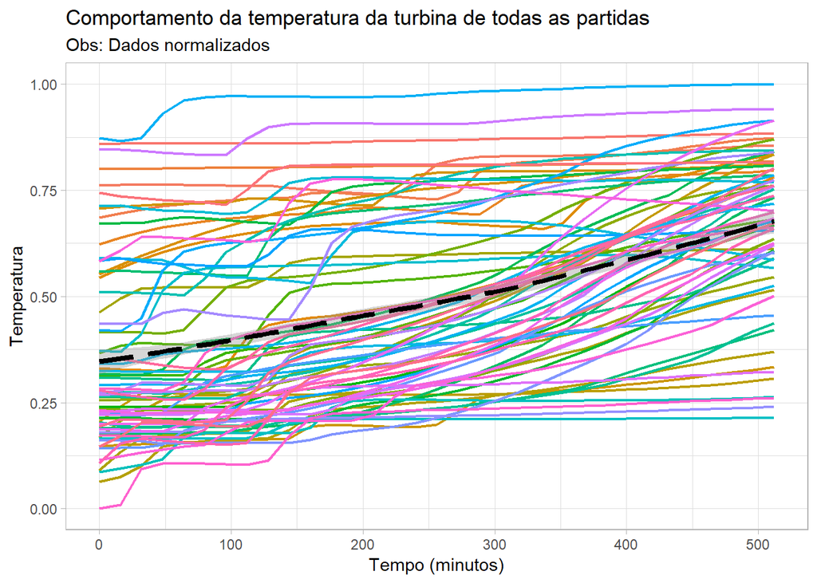

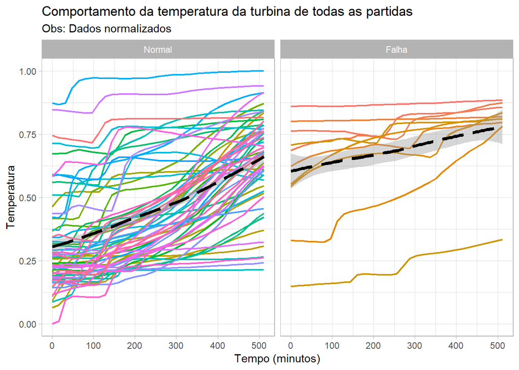

```r
# Comportamento geral das turbinas----

g.total <- dados_t %>%
  cbind(falhas$Instantes) %>%
  melt(id.vars = "falhas$Instantes") %>%
  mutate(tempo = `falhas$Instantes`) %>%
  select(-`falhas$Instantes`) %>%
  ggplot(mapping = aes(x = tempo, y = value)) +
  geom_line(mapping = aes(color = variable), size = 0.75) +
  theme_light() +
  labs(title = "Comportamento da temperatura da turbina de todas as partidas",
       x = "Tempo (minutos)", y = "Temperatura",
       subtitle = "Obs: Dados normalizados") +
  theme(legend.position="none") +
  geom_smooth(method = "loess", se = TRUE, color = "black", size = 1.5, linetype = 5)
g.total

g.div <- dados_t %>%
  cbind(falhas$Instantes) %>%
  melt(id.vars = "falhas$Instantes") %>%
  mutate(tempo = `falhas$Instantes`,
         operacao = ifelse(grepl("Falha", variable) == T, "Falha", "Normal")) %>%
  mutate(operacao = factor(operacao, levels = c("Normal", "Falha"))) %>%
  select(-`falhas$Instantes`) %>%
  ggplot(mapping = aes(x = tempo, y = value)) +
  geom_line(mapping = aes(color = variable), size = 0.75) +
  theme_light() +
  labs(title = "Comportamento da temperatura da turbina de todas as partidas",
       x = "Tempo (minutos)", y = "Temperatura",
       subtitle = "Obs: Dados normalizados") +
  theme(legend.position="none") +
  facet_wrap(facets = ~operacao, nrow = 1) +
  geom_smooth(method = "loess", se = TRUE, color = "black", size = 1.5, linetype = 5)
g.div
```

*A representação inicial indica que as partidas que falharam tendem a começar com uma temperatura mais eleveda do que as partidas normais.*

*Para aplicação do FCM pode-se utilizar a função* `fanny()` *do pacote **cluster**. Um dos argumentos dessa função é o “metric”, através dele é possível definir que a métrica de distância utilizada seja a euclidiana.*

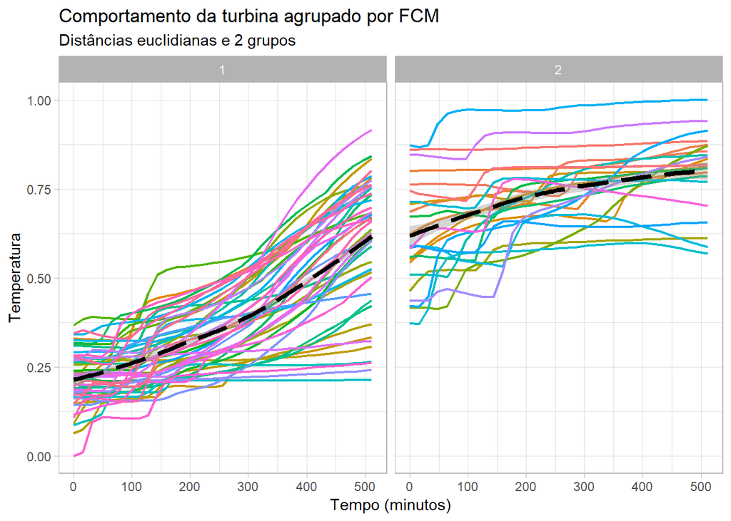

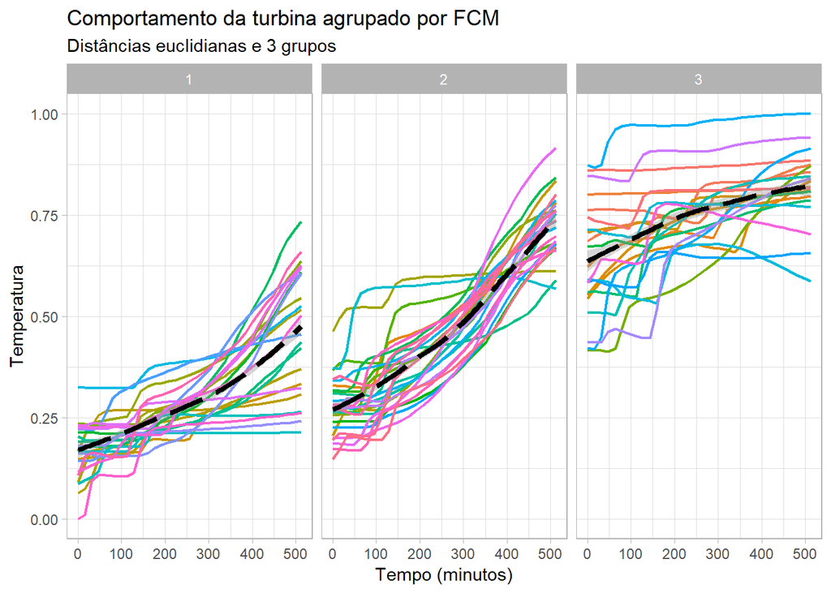

```r
# Letra (a)----

# Aplicando FCM - 2 grupos (Distancia Euclidiana)
d_a_2 <- fanny(T_dados_t, k = 2, metric = "euclidean", stand = FALSE)

d1 <- dados_t %>%
  cbind(falhas$Instantes) %>%
  melt(id.vars = "falhas$Instantes") %>%
  mutate(tempo = `falhas$Instantes`,
         operacao = ifelse(grepl("Falha", variable) == T, "Falha", "Normal")) %>%
  select(-`falhas$Instantes`) %>%
  mutate(operacao = factor(operacao, levels = c("Normal", "Falha")))

d2 <- as.data.frame(t(d_a_2$clustering)) %>%
  melt() %>%
  mutate(op = ifelse(grepl("Normal", variable) == T, 1, 2))

dt.1 <- left_join(d1, d2, by = c("variable")) %>%
  mutate(temperatura = value.x, grupo = value.y) %>%
  select(-value.x, -value.y) %>%
  mutate(grupo = ifelse(grupo == 1, 3, grupo),
         grupo = ifelse(grupo == 2, 1, 2))

g.a.1 <- dt.1 %>%
  ggplot(mapping = aes(x = tempo, y = temperatura)) +
  geom_line(mapping = aes(color = variable), size = 0.75) +
  theme_light() +
  labs(title = "Comportamento da turbina agrupado por FCM",
       x = "Tempo (minutos)", y = "Temperatura",
       subtitle = "Distâncias euclidianas e 2 grupos") +
  theme(legend.position="none") +
  geom_smooth(method = "loess", se = TRUE, color = "black", size = 1.5, linetype = 5) +
  facet_wrap(facets = ~grupo, nrow = 1)
g.a.1

# Aplicando FCM - 3 grupos (Distancia Euclidiana)
d_a_3 <- fanny(T_dados_t, k = 3, metric = "euclidean", stand = FALSE)

d3 <- as.data.frame(t(d_a_3$clustering)) %>%
  melt()

dt.2 <- left_join(d1, d3, by = c("variable")) %>%
  mutate(temperatura = value.x, grupo = value.y) %>%
  select(-value.x, -value.y) %>%
  mutate(grupo = ifelse(grupo == 3, 4, grupo),
         grupo = ifelse(grupo == 1, 3, grupo),
         grupo = ifelse(grupo == 4, 1, grupo))

g.a.2 <- dt.2 %>%
  ggplot(mapping = aes(x = tempo, y = temperatura)) +
  geom_line(mapping = aes(color = variable), size = 0.75) +
  theme_light() +
  labs(title = "Comportamento da turbina agrupado por FCM",
       x = "Tempo (minutos)", y = "Temperatura",
       subtitle = "Distâncias euclidianas e 3 grupos") +
  theme(legend.position="none") +
  geom_smooth(method = "loess", se = TRUE, color = "black", size = 1.5, linetype = 5) +
  facet_wrap(facets = ~grupo, nrow = 1)
g.a.2
```

*A aplicação do FCM para 2 grupos segue a tendência indicada na representação inicial, o que se percebe como principal diferença é que após o agrupamento algumas partidas normais que começaram em altas temperaturas foram para o grupo 2, das “falhas”, e as partidas de falha que começaram em baixas temperaturam foram para o grupo 1, das partidas normais.*

*Já a aplicação para 3 grupos, percebe-se que o grupo das “falhas”, que dessa vez é o 3, permanece sem muita alteração, já o grupo de partidas normais foi dividido em dois. Trazendo essas interpretações para o estudo de caso, pode-se indicar como mais apropriada a aplicação do FCM para 2 grupos, onde é possível investigar o agrupamento que representa a maioria das partidas de falha e o agrupamento de partidas normais.*

### FCM (DTW)

**b)** Aplicar o FCM, com a distância DTW, com 2 e 3 grupos. Neste caso a função FCM intrínseca do matlab não se aplica porque está baseada na distância Euclideana (portanto, é necessário rodar otimização calculando a distância do objeto ao centro através do DTW). O matlab possui a função DTW.

*Como a função função* `fanny()` *do pacote **cluster** não permite escolher DTW como metrica, a função utilizada para aplicar o FCM é o* `tsclust()` *do pacote **dtwclust**, onde os argumentos “type” e “distance” permitem definir o tipo fuzzy de argupamento e o método DTW para a distância.*

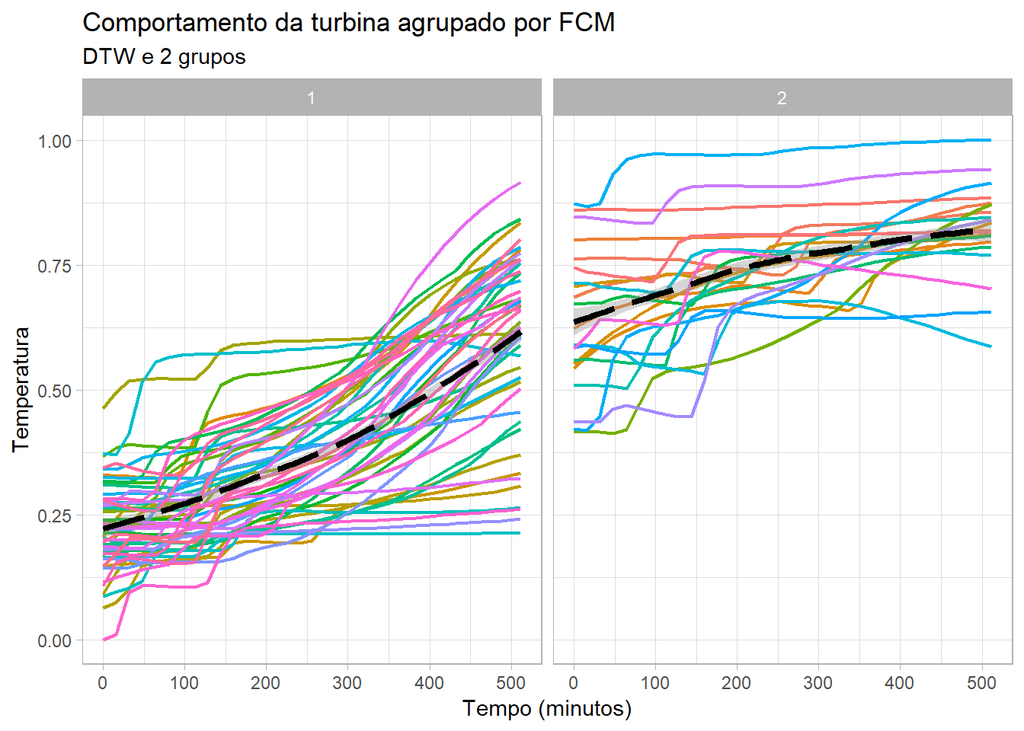

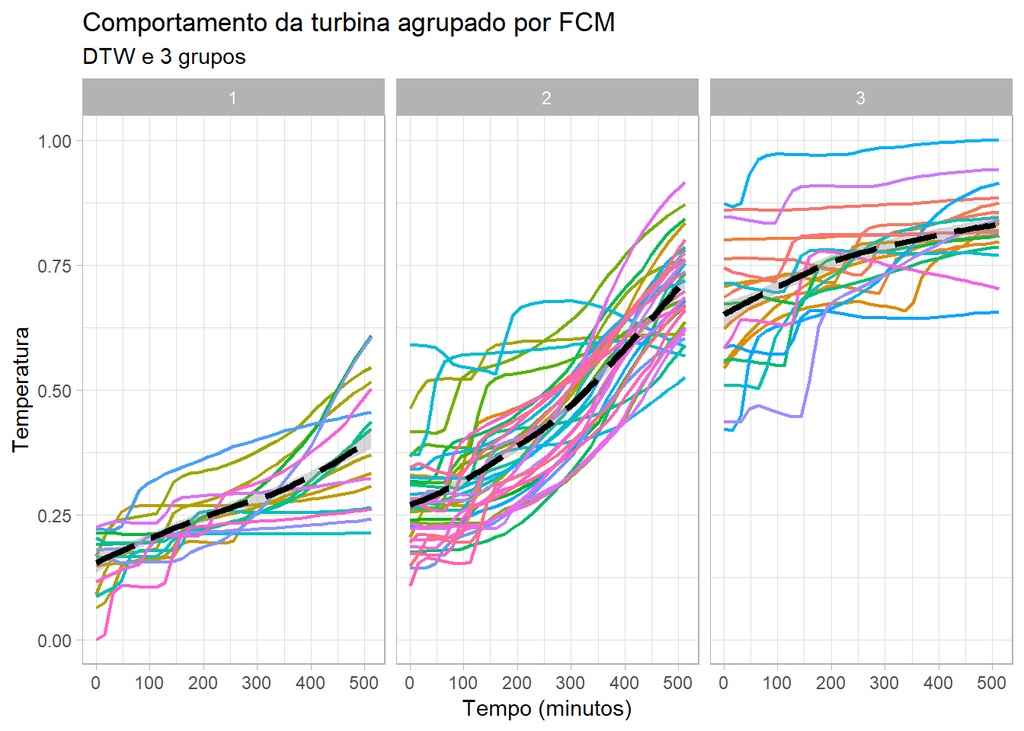

```r
# Aplicando FCM usando dtw para 2 grupos
d_dtw.1 <- tsclust(series = T_dados_t, type = "fuzzy", k = 2L, distance = "dtw", centroid = "fcm")

d2.b <- as.data.frame(t(d_a_2$clustering)) %>%
  rbind(d_dtw.1@cluster) %>%
  slice(-1) %>%
  melt() %>%
  mutate(op = ifelse(grepl("Normal", variable) == T, 1, 2))

dt.1.b <- left_join(d1, d2.b, by = c("variable")) %>%
  mutate(temperatura = value.x, grupo = value.y) %>%
  select(-value.x, -value.y)

g.b.1 <- dt.1.b %>%
  ggplot(mapping = aes(x = tempo, y = temperatura)) +
  geom_line(mapping = aes(color = variable), size = 0.75) +
  theme_light() +
  labs(title = "Comportamento da turbina agrupado por FCM",
       x = "Tempo (minutos)", y = "Temperatura",
       subtitle = "DTW e 2 grupos") +
  theme(legend.position="none") +
  geom_smooth(method = "loess", se = TRUE, color = "black", size = 1.5, linetype = 5) +
  facet_wrap(facets = ~grupo, nrow = 1)
g.b.1

# Aplicando FCM usando dtw para 3 grupos
d_dtw.2 <- tsclust(series = T_dados_t, type = "fuzzy", k = 3L, distance = "dtw", centroid = "fcm")

d3.b <- as.data.frame(t(d_a_2$clustering)) %>%
  rbind(d_dtw.2@cluster) %>%
  slice(-1) %>%
  melt()

dt.2.b <- left_join(d1, d3.b, by = c("variable")) %>%
  mutate(temperatura = value.x, grupo = value.y) %>%
  select(-value.x, -value.y)

g.b.2 <- dt.2.b %>%
  ggplot(mapping = aes(x = tempo, y = temperatura)) +
  geom_line(mapping = aes(color = variable), size = 0.75) +
  theme_light() +
  labs(title = "Comportamento da turbina agrupado por FCM",
       x = "Tempo (minutos)", y = "Temperatura",
       subtitle = "DTW e 3 grupos") +
  theme(legend.position="none") +
  geom_smooth(method = "loess", se = TRUE, color = "black", size = 1.5, linetype = 5) +
  facet_wrap(facets = ~grupo, nrow = 1)
g.b.2
```

*Visivelmente a diferença entre o FCM usando a distância euclidiana e o FCM usando o DTW é bem pequena, então uma matriz de confusão é gerada considerando a abordagem de 2 grupos para os resultados da letra a) e letra b). Para isso a função* `confusionMatrix()` *do pacote **caret** é utilizada.*

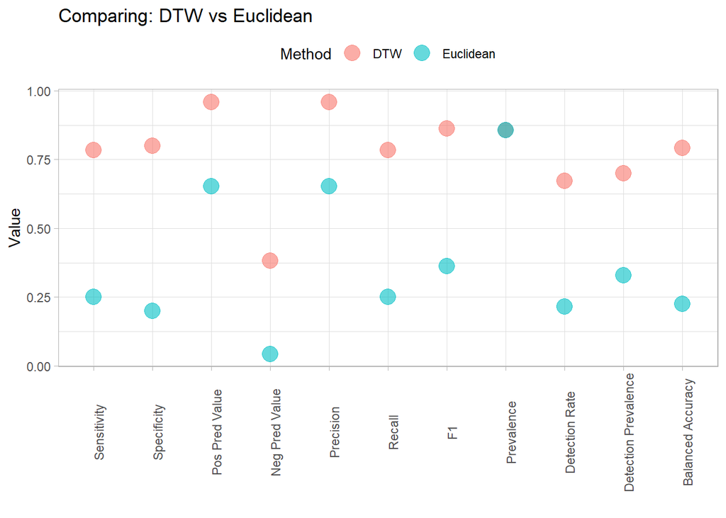

```r
# Comparando matriz de confusão de A(Euclidiana) x B(DTW)
dx.a <- confusionMatrix(table(d2$value, d2$op))

dx.a <- as.data.frame(t(dx.a$byClass)) %>%
  melt()

dx.b <- confusionMatrix(table(d2.b$value, d2.b$op))

dx.b <- as.data.frame(t(dx.b$byClass)) %>%
  melt() %>%
  left_join(dx.a, by = "variable") %>%
  rename("index" = variable, "DTW" = value.x, "Euclidean" = value.y) %>%
  melt() %>%
  rename("Method" = variable)

g.compare.1 <- ggplot(dx.b) +
  geom_point(mapping = aes(x = index, y = value, color = Method), size = 5, alpha = 0.6) +
  theme_light() +
  labs(title = "Comparing: DTW vs Euclidean",
       x = "", y = "Value") +
  theme(legend.position="top") +
 theme(axis.text.x = element_text(angle = 90))
g.compare.1
```

*Observando o resultado gráfico é possível indicar o método DTW como superior. Apenas na prevalência os métodos se equivalem, em todos os outrso o DTW apresenta um desempenho superior.*

### Fusão

**1** - Verificar se houve coalescência/fusão entre os grupos (o que indica que não houve sucesso no agrupamento);

*O índice de silhueta varia de −1 a +1, em que um valor alto indica que o objeto é bem compatível com seu próprio cluster e mal combinado com os clusters vizinhos. Se a maioria dos objetos tiver um valor alto, a configuração de cluster será apropriada. Então através da função* `fviz_silhouette()` *do pacote **factoextra** é possível representar gráficamente o índice para os objetos dos grupos.*

```
FALSE   cluster size ave.sil.width
FALSE 1       1   23           0.6
FALSE 2       2   47           0.6
```

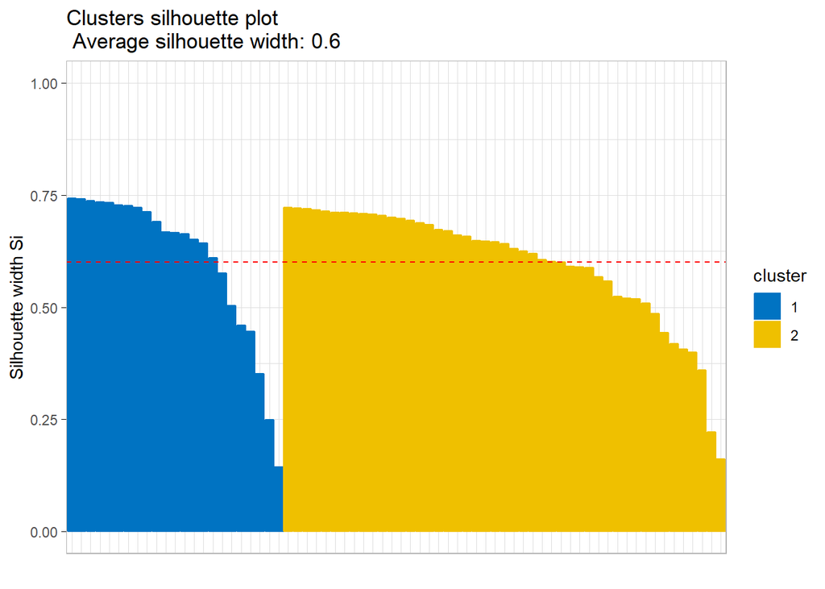

```
FALSE   cluster size ave.sil.width
FALSE 1       1   21          0.55
FALSE 2       2   26          0.47
FALSE 3       3   23          0.43
```

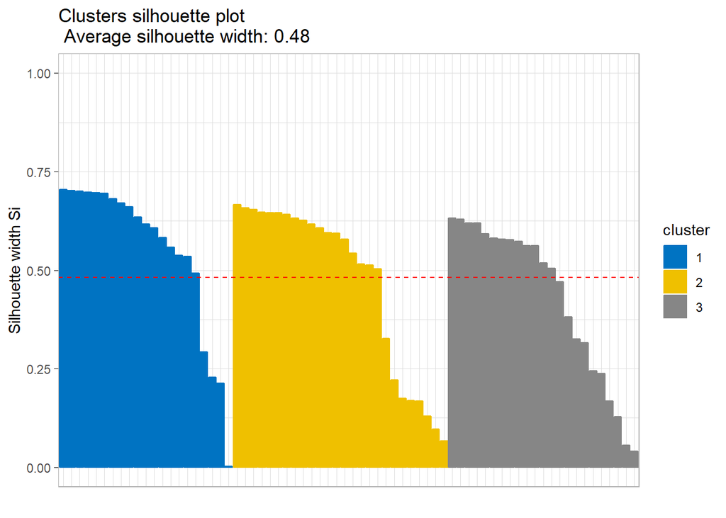

```r
# Avaliando a qualidade do agrupamento para 2 grupos
g.sil.2 <- fviz_silhouette(d_a_2, palette = "jco", ggtheme = theme_light())
g.sil.2

# Avaliando a qualidade do agrupamento para 3 grupos
g.sil.3 <- fviz_silhouette(d_a_3, palette = "jco", ggtheme = theme_light())
g.sil.3
```

*A aplicação do silhueta aos resultados da letra a) indica que as abordagens podem ser consideradas satisfatórias, sendo o agrupamento por 2 grupos o que retorna melhor índice. Trazendo para interpretação do problema, já era esparo que a abordagem por 2 grupos fosse a mais indicada, já que deseja-se entender os padrões de falha.*

### Padrões

**2** - Verificar os padrões reconhecidos.

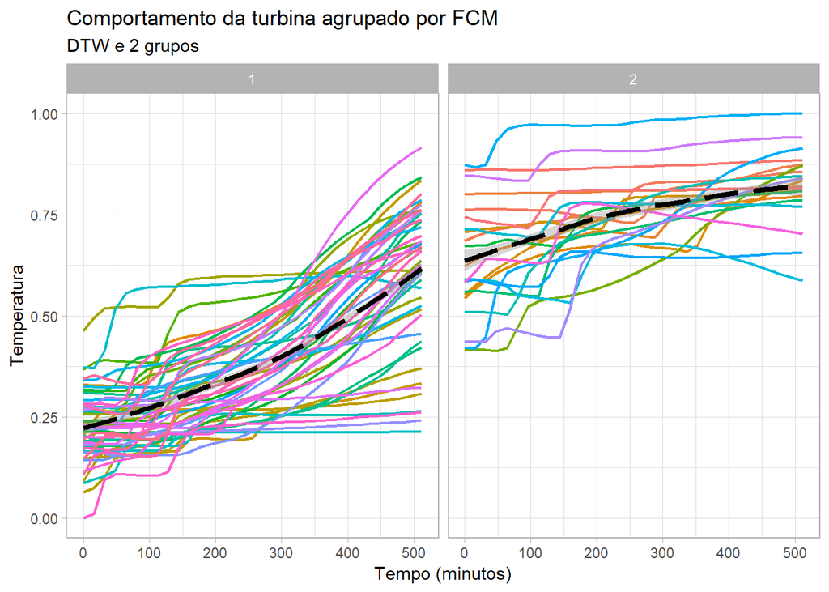

```r
g.b.1
```

*Considerando a aplicação do FCM utilizando DTW, já que apresenta um desempenho melhor do que utilizando a métrica euclidiana, para uma abordagem de 2 grupos, por apresentar um índice de silhueta maior do que para 3 grupos, é possível entender que o grupo de interesse ainda mantém a característica da investigação inicial, ou seja, o agrupamento que representa o grupo de partidas que falharam continua com uma curva de tendência parecida, a partida já começa com uma temperatua elevada em comparação com as partidas normais.*

```r
confusionMatrix(table(d2.b$value, d2.b$op))$overall
```

```
FALSE       Accuracy          Kappa  AccuracyLower  AccuracyUpper   AccuracyNull
FALSE    0.785714286    0.400000000    0.671314855    0.874816429    0.857142857
FALSE AccuracyPValue  McnemarPValue
FALSE    0.963986339    0.009823275
```

*Calculando a acurácia através da função* `confusionMatrix()` *do pacote **caret** que já foi utilizada em outro momento desse mesmo desenvolvimento, o agrupamento em análise retorna um valor de **0.7857**.*

### Observação:

**Se você está tentando reproduzir este código talvez o gráfico “Comparing: DTW vs Euclidean” e os valores de acurácia apresentados não sejam os mesmos que você encontrou. Isso se deve a um problema que encontrei de combinar os levels dos agrupamentos, aparentemente por mais que eu “set” os levels dos grupos, a função nomeia de forma aleatória quem é o “grupo 1” e quem é o “grupo 2”. Seguem abaixo alguns links que podem ajudar a solucionar este problema.**

- https://stackoverflow.com/questions/5490638/how-to-change-the-order-of-facet-labels-in-ggplot-custom-facet-wrap-labels
- https://stackoverflow.com/questions/15116081/controlling-order-of-facet-grid-facet-wrap-in-ggplot2
- https://stackoverflow.com/questions/18413756/re-ordering-factor-levels-in-data-frame

**Discentes:**  
**[Brenner Silva](http://lattes.cnpq.br/8005291514473676)**;  
**[Herica Oliveira](http://lattes.cnpq.br/4181714806448813)**;  
**[Lucas Mascarenhas](http://lattes.cnpq.br/9440856373742866)**.

**Docentes:**  
**[Cristiano Fontes](http://lattes.cnpq.br/8533422209857268)**;  
**[Karla Esquerre](http://lattes.cnpq.br/1956096628005272)**.

[figure not shown]